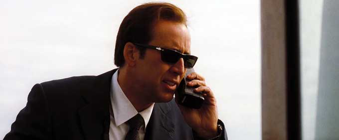

# Can we find the fights that haven't started yet ?

By Jacob James(UID: 116038324) and Josh Stringfield (UID: 116299619)

## Introduction

Your first question must be: why is Nicholas Cage in a reputable project? Thankfully he does not play a part in later parts of this production. In the Film Lord of War, Nick Cage plays the role of an Arms Dealer set in the Cold War Era. The character of Nick Cage and the realtive ease at which he sold weapons got my partner and I thinking. Do nations who spend aggressively on arms in a short period of time, say 5-10 years, are more likely to engage in an act of hostility ? Using this reasoning can we identify the real "Lord of War" in our time period ?

The world spends close to 3 trillion dollars every year on military expenditures.Yet the world seems to be a more and more dangerous place as the days progress. Between 1950 to present day, the world has been embroiled in countless fights and wars. Everyone who has played a few strategy games here and there understands that any player working on maintaining a large standing army: isn't trying to build hospitals or develop infrastructure; they intend to attack someone. I am here to attempt to prove my hypothesis,using historical and financial data, that Nations who spend heavily on weapons imports, in a relatively short period of time, intend to use those arms to engage in combat ? If a trend can be observed historically, can we use the said trend to predict what countries will most likely engage in acts of aggression in the 21st century?

```python
import pandas as pd
import numpy as np
import math as math
import matplotlib.pyplot as plt
import statsmodels.api as sm
from statsmodels.formula.api import ols
from sklearn.linear_model import LinearRegression
from sklearn.model_selection import cross_val_predict
from sklearn import datasets, svm, tree
from scipy import stats
from scipy.stats import linregress

# for linear regression
from sklearn import linear_model
from scipy import stats
```

### Source

The source we will be using for this project is the Stockholm International Peace Research Institute database(https://www.sipri.org/about). SIPRI is an independent international institute. They have little reason to fudge the numbers as it's simply for the public to be made aware. There would be little to no bias as individual nations would use their intelligence networks to produce their own counts of foreign weapons purchases. We will be able to produce the total value of the international arms trade into a simple CSV file broken down by year and country.

### Limitations

The data is provided by all countries/entities between 1950-2020 that ordered anywhere between none to 25 billion dollars worth of arms. However, the limitations of this data include not accounting for domestic arms production,the black market, and legacy vehicles/present arsenal(i.e. airplanes,tanks). For example, the US could be considered one of the biggest if not the biggest aggressor in the time period we are looking at. However, the US is the world's biggest arms exporter and really has no problem in equipping their forces. Therefore the data will not be able to reflect that. The hypothesis we wish to find an answer to is if a short burst of high volume purchases resulted in a conflict or were in preparation of a conflict.

The data also might be misleading as it starts in 1950, so nations like Germany and Japan heavily rely on foreign arms imports for national defense while not necessarily being aggressive.

The data is also limited to small firearms all the way to communication satellites and everything in between. However, does not include purchases of blunt objects or knives. Several bloody events, like the Rwandan genocide, was preparated by using weapons like such. So we are unable to account for events that did not include weapons that the database looks for. Supplementing this data would've been difficult as we cannot determine if the nation had a sudden demand for cooking knives or have malicious intent.

```python
arms_sales = pd.read_csv('TIV-Import-All-1950-2020.csv')

# Filling all the NaN values with 0.0 for later calculation
arms_sales.fillna(value=0, inplace=True)
arms_sales_original = arms_sales
arms_sales.head()
```

|  | Country | 1950 | 1951 | 1952 | 1953 | 1954 | 1955 | 1956 | 1957 | 1958 | ... | 2012 | 2013 | 2014 | 2015 | 2016 | 2017 | 2018 | 2019 | 2020 | Total |
| --- | --- | --- | --- | --- | --- | --- | --- | --- | --- | --- | --- | --- | --- | --- | --- | --- | --- | --- | --- | --- | --- |
| 0 | Afghanistan | 0.0 | 0.0 | 0.0 | 0.0 | 0.0 | 4.0 | 7.0 | 89.0 | 254.0 | ... | 523.0 | 235.0 | 288.0 | 116.0 | 174.0 | 252.0 | 349.0 | 382.0 | 227.0 | 16391.0 |
| 1 | African Union** | 0.0 | 0.0 | 0.0 | 0.0 | 0.0 | 0.0 | 0.0 | 0.0 | 0.0 | ... | 0.0 | 2.0 | 0.0 | 2.0 | 0.0 | 0.0 | 0.0 | 4.0 | 0.0 | 79.0 |
| 2 | Albania | 20.0 | 10.0 | 11.0 | 20.0 | 22.0 | 132.0 | 98.0 | 42.0 | 47.0 | ... | 15.0 | 7.0 | 7.0 | 7.0 | 0.0 | 4.0 | 2.0 | 5.0 | 0.0 | 2771.0 |
| 3 | Algeria | 0.0 | 0.0 | 0.0 | 0.0 | 0.0 | 0.0 | 0.0 | 0.0 | 0.0 | ... | 661.0 | 362.0 | 620.0 | 898.0 | 2903.0 | 1128.0 | 1284.0 | 164.0 | 549.0 | 32139.0 |
| 4 | Amal (Lebanon)* | 0.0 | 0.0 | 0.0 | 0.0 | 0.0 | 0.0 | 0.0 | 0.0 | 0.0 | ... | 0.0 | 0.0 | 0.0 | 0.0 | 0.0 | 0.0 | 0.0 | 0.0 | 0.0 | 60.0 |

5 rows × 73 columns

## Data Tidying

```python
# Sorting the values by the 'Total' of the row to find the highest values in the data.

arms_sales.sort_values(by=['Total'], ascending=False, inplace=True)
```

```python
# Rearranging values, bringing 'Total' to the first column in the df.

cols = arms_sales.columns.tolist()
cols = cols[-1:] + cols[:-1]
# cols

arms_sales = arms_sales[cols]
arms_sales.head()
```

|  | Total | Country | 1950 | 1951 | 1952 | 1953 | 1954 | 1955 | 1956 | 1957 | ... | 2011 | 2012 | 2013 | 2014 | 2015 | 2016 | 2017 | 2018 | 2019 | 2020 |
| --- | --- | --- | --- | --- | --- | --- | --- | --- | --- | --- | --- | --- | --- | --- | --- | --- | --- | --- | --- | --- | --- |
| 260 | 1973386.0 | Total | 8139.0 | 11497.0 | 16533.0 | 24027.0 | 20371.0 | 20147.0 | 24262.0 | 23556.0 | ... | 30043.0 | 27995.0 | 27174.0 | 27073.0 | 28638.0 | 31438.0 | 31762.0 | 27028.0 | 27105.0 | 22831.0 |
| 94 | 126727.0 | India | 141.0 | 277.0 | 104.0 | 430.0 | 265.0 | 350.0 | 366.0 | 980.0 | ... | 3598.0 | 4392.0 | 5381.0 | 3347.0 | 3117.0 | 3003.0 | 2909.0 | 1485.0 | 3075.0 | 2799.0 |
| 39 | 80828.0 | China | 2572.0 | 2197.0 | 3430.0 | 3144.0 | 3500.0 | 1730.0 | 2255.0 | 2126.0 | ... | 1055.0 | 1571.0 | 1289.0 | 1077.0 | 1262.0 | 1139.0 | 1338.0 | 1962.0 | 1347.0 | 811.0 |
| 193 | 70781.0 | Saudi Arabia | 0.0 | 0.0 | 7.0 | 1.0 | 2.0 | 16.0 | 10.0 | 72.0 | ... | 1222.0 | 1033.0 | 1614.0 | 2740.0 | 3377.0 | 2961.0 | 3931.0 | 3315.0 | 3419.0 | 2466.0 |
| 58 | 67745.0 | Egypt | 163.0 | 57.0 | 0.0 | 1.0 | 142.0 | 725.0 | 1065.0 | 479.0 | ... | 630.0 | 281.0 | 673.0 | 420.0 | 1436.0 | 1690.0 | 2395.0 | 1677.0 | 1046.0 | 1311.0 |

5 rows × 73 columns

```python
# Dropping row that is the total of all values. Not useful for the analysis. This part is optional.

arms_sales = arms_sales.drop(labels=[260], axis=0)
arms_sales.head()
```

|  | Total | Country | 1950 | 1951 | 1952 | 1953 | 1954 | 1955 | 1956 | 1957 | ... | 2011 | 2012 | 2013 | 2014 | 2015 | 2016 | 2017 | 2018 | 2019 | 2020 |
| --- | --- | --- | --- | --- | --- | --- | --- | --- | --- | --- | --- | --- | --- | --- | --- | --- | --- | --- | --- | --- | --- |
| 94 | 126727.0 | India | 141.0 | 277.0 | 104.0 | 430.0 | 265.0 | 350.0 | 366.0 | 980.0 | ... | 3598.0 | 4392.0 | 5381.0 | 3347.0 | 3117.0 | 3003.0 | 2909.0 | 1485.0 | 3075.0 | 2799.0 |
| 39 | 80828.0 | China | 2572.0 | 2197.0 | 3430.0 | 3144.0 | 3500.0 | 1730.0 | 2255.0 | 2126.0 | ... | 1055.0 | 1571.0 | 1289.0 | 1077.0 | 1262.0 | 1139.0 | 1338.0 | 1962.0 | 1347.0 | 811.0 |
| 193 | 70781.0 | Saudi Arabia | 0.0 | 0.0 | 7.0 | 1.0 | 2.0 | 16.0 | 10.0 | 72.0 | ... | 1222.0 | 1033.0 | 1614.0 | 2740.0 | 3377.0 | 2961.0 | 3931.0 | 3315.0 | 3419.0 | 2466.0 |
| 58 | 67745.0 | Egypt | 163.0 | 57.0 | 0.0 | 1.0 | 142.0 | 725.0 | 1065.0 | 479.0 | ... | 630.0 | 281.0 | 673.0 | 420.0 | 1436.0 | 1690.0 | 2395.0 | 1677.0 | 1046.0 | 1311.0 |
| 103 | 65890.0 | Japan | 0.0 | 0.0 | 8.0 | 223.0 | 314.0 | 408.0 | 757.0 | 1059.0 | ... | 268.0 | 205.0 | 252.0 | 307.0 | 329.0 | 330.0 | 441.0 | 654.0 | 899.0 | 724.0 |

5 rows × 73 columns

#### Data Frame Structure

This above data frame is a good example as to what the sub dataframes will look like

1. Total will be the total arms imports, in the million, for the nation between the start and end time interval
2. 1951-2020: The years will have a value, to be refered in the millions (for exampke 10 = 10 million), which is an individual nations respective import amount for that year
3. Country: The Country whose row data is populated for

## Data management/representation

```python
#Create a sum for the rows for each country, for plotting
df_1950_1960 = arms_sales[["Country",'1950','1951','1952','1953','1954','1955','1956','1957','1958', '1959']].copy(deep=True)
df_1950_1960["sum"] = df_1950_1960.sum(axis=1)
df_1960_1970 = arms_sales[["Country",'1960','1961','1962','1963','1964','1965','1966','1967','1968', '1969']].copy(deep=True)
df_1960_1970["sum"] = df_1960_1970.sum(axis=1)
df_1970_1980 = arms_sales[["Country",'1970','1971','1972','1973','1974','1975','1976','1977','1978', '1979']].copy(deep=True)
df_1970_1980["sum"] = df_1970_1980.sum(axis=1)
df_1980_1990 = arms_sales[["Country",'1980','1981','1982','1983','1984','1985','1986','1987','1988', '1989']].copy(deep=True)
df_1980_1990["sum"] = df_1980_1990.sum(axis=1)
df_1990_2000 = arms_sales[["Country",'1990','1991','1992','1993','1994','1995','1996','1997','1998', '1999']].copy(deep=True)
df_1990_2000["sum"] = df_1990_2000.sum(axis=1)
df_2000_2010 = arms_sales[["Country",'2000','2001','2002','2003','2004','2005','2006','2007','2008', '2009']].copy(deep=True)
df_2000_2010["sum"] = df_2000_2010.sum(axis=1)
df_2010_2020 = arms_sales[["Country",'2010','2011','2012','2013','2014','2015','2016','2017','2018', '2019','2020']].copy(deep=True)
df_2010_2020["sum"] = df_2010_2020.sum(axis=1)

#Drop the unnecssary row from data frame
df_1950_1960.reset_index(drop=True, inplace=True)
df_1950_1960 = df_1950_1960.drop(labels=[434], axis=0)

df_1960_1970.reset_index(drop=True, inplace=True)
df_1960_1970 = df_1960_1970.drop(labels=[434], axis=0)

df_1970_1980.reset_index(drop=True, inplace=True)
df_1970_1980 = df_1970_1980.drop(labels=[434], axis=0)


df_1980_1990.reset_index(drop=True, inplace=True)
df_1980_1990 = df_1980_1990.drop(labels=[434], axis=0)


df_1990_2000.reset_index(drop=True, inplace=True)
df_1990_2000 = df_1990_2000.drop(labels=[434], axis=0)


df_2000_2010.reset_index(drop=True, inplace=True)
df_2000_2010 = df_2000_2010.drop(labels=[434], axis=0)

df_2010_2020.reset_index(drop=True, inplace=True)
df_2010_2020 = df_2010_2020.drop(labels=[434], axis=0)

#Remove duplicate rows
df_1950_1960 = df_1950_1960.drop_duplicates()
df_1960_1970 = df_1960_1970.drop_duplicates()
df_1970_1980 = df_1970_1980.drop_duplicates()
df_1980_1990 = df_1980_1990.drop_duplicates()
df_1990_2000 = df_1990_2000.drop_duplicates()
df_2000_2010 = df_2000_2010.drop_duplicates()
df_2010_2020 = df_2010_2020.drop_duplicates()

#Sort by total import sum
df_1950_1960.sort_values(by=['sum'], inplace=True,ascending=False)
df_1960_1970.sort_values(by=['sum'], inplace=True,ascending=False)
df_1970_1980.sort_values(by=['sum'], inplace=True,ascending=False)
df_1980_1990.sort_values(by=['sum'], inplace=True,ascending=False)
df_1990_2000.sort_values(by=['sum'], inplace=True,ascending=False)
df_2000_2010.sort_values(by=['sum'], inplace=True,ascending=False)
df_2010_2020.sort_values(by=['sum'], inplace=True,ascending=False)

#Get the top 50
top_50_1950_1960 = df_1950_1960.head(50).copy(deep=True)
top_50_1960_1970 = df_1960_1970.head(50).copy(deep=True)
top_50_1970_1980 = df_1970_1980.head(50).copy(deep=True)
top_50_1980_1990 = df_1980_1990.head(50).copy(deep=True)
top_50_1990_2000 = df_1990_2000.head(50).copy(deep=True)
top_50_2000_2010 = df_2000_2010.head(50).copy(deep=True)
top_50_2010_2020 = df_2010_2020.head(50).copy(deep=True)

#Get the column totals from each year, for linear regression
_1950_1960_float = list(top_50_1950_1960.sum(axis=0))
_1960_1970_float = list(top_50_1960_1970.sum(axis=0))
_1970_1980_float = list(top_50_1970_1980.sum(axis=0))
_1980_1990_float = list(top_50_1980_1990.sum(axis=0))
_1990_2000_float = list(top_50_1990_2000.sum(axis=0))
_2000_2010_float = list(top_50_2000_2010.sum(axis=0))
_2010_2020_float = list(top_50_2010_2020.sum(axis=0))

#year arrays for linear regression use
year_1950_1960 = [1950,1951,1952,1953,1954,1955,1956,1957,1958,1959]
year_1960_1970 = [1960,1961,1962,1963,1964,1965,1966,1967,1968,1969]
year_1970_1980 = [1970,1971,1972,1973,1974,1975,1976,1977,1978,1979]
year_1980_1990 = [1980,1981,1982,1983,1984,1985,1986,1987,1988,1989]
year_1990_2000 = [1990,1991,1992,1993,1994,1995,1996,1997,1998,1999]
year_2000_2010 = [2000,2001,2002,2003,2004,2005,2006,2007,2008,2009]
year_2010_2020 = [2010,2011,2012,2013,2014,2015,2016,2017,2018,2019,2020]

#remove last element as it sums up the sum
del _1950_1960_float[-1]
del _1960_1970_float[-1]
del _1970_1980_float[-1]
del _1980_1990_float[-1]
del _1990_2000_float[-1]
del _2000_2010_float[-1]
del _2010_2020_float[-1]

#some how adds up the strings as concatention
del _1950_1960_float[0]
del _1960_1970_float[0]
del _1970_1980_float[0]
del _1980_1990_float[0]
del _1990_2000_float[0]
del _2000_2010_float[0]
del _2010_2020_float[0]

#Create Np arrays for plotting
_1950_1960 = np.array(_1950_1960_float, dtype = np.int32)
_1960_1970 = np.array(_1960_1970_float, dtype = np.int32)
_1970_1980 = np.array(_1970_1980_float, dtype = np.int32)
_1980_1990 = np.array(_1980_1990_float, dtype = np.int32)
_1990_2000 = np.array(_1990_2000_float, dtype = np.int32)
_2000_2010 = np.array(_2000_2010_float, dtype = np.int32)
_2010_2020 = np.array(_2010_2020_float, dtype = np.int32)

#Dividing by 50 to get the average
_1950_1960 = np.divide(_1950_1960, 50)
_1960_1970 = np.divide(_1960_1970, 50)
_1970_1980 = np.divide(_1970_1980, 50)
_1980_1990 = np.divide(_1980_1990, 50)
_1990_2000 = np.divide(_1990_2000, 50)
_2000_2010 = np.divide(_2000_2010, 50)
_2010_2020 = np.divide(_2010_2020, 50)
```

Below is the plotting function, which plots the country scatter points through a year vs imports

```python
def scatter_years_imports(data_frame):
    countries = data_frame['Country'].tolist()
    years = data_frame.columns.tolist()[1:11]
    country_list = list(set(countries))
    year_values = []
    imports = []
    for country in countries:
        for year in years:
            country_to_color = { i : np.random.rand(3,) for i in country_list }
            if len(data_frame.index[data_frame['Country'] == country]) > 0:
                country_index = data_frame.index[data_frame['Country'] == country][0]
                import_value = data_frame.at[country_index, year]
                temp_year = int(year)
                plt.legend(bbox_to_anchor=(1.05, 1), ncol=2, loc="upper left", labels=country_list)
                plt.rc('figure', figsize=(10, 10))
                plt.scatter(temp_year, import_value, color=country_to_color[country])
```

We are now going to look at the tendency of the data to identify skewness and the distribution of the numerical data through a box plot.

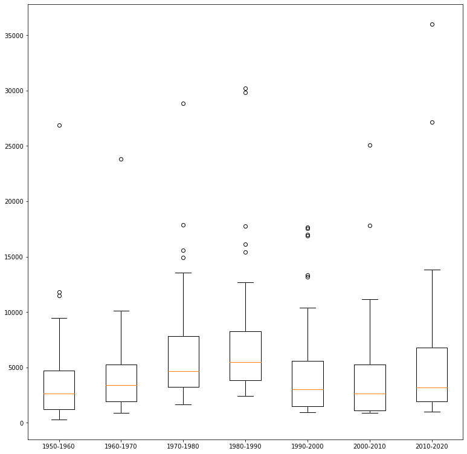

```python
#Just setting the sum of the varios top 50, 10 year intervals to numpy arrays for graphing

sum_1950_1960 = top_50_1950_1960["sum"].to_numpy()
sum_1960_1970 = top_50_1960_1970["sum"].to_numpy()
sum_1970_1980 = top_50_1970_1980["sum"].to_numpy()
sum_1980_1990 = top_50_1980_1990["sum"].to_numpy()
sum_1990_2000 = top_50_1990_2000["sum"].to_numpy()
sum_2000_2010 = top_50_2000_2010["sum"].to_numpy()
sum_2010_2020 = top_50_2010_2020["sum"].to_numpy()

#Graphing
data = [sum_1950_1960, sum_1960_1970, sum_1970_1980, sum_1980_1990,sum_1990_2000,sum_2000_2010,sum_2010_2020]
fig = plt.figure(figsize =(10, 10))
ax = fig.add_axes([0, 0, 1, 1])
ax.set_xticklabels(["1950-1960", "1960-1970", "1970-1980", "1980-1990","1990-2000","2000-2010","2010-2020"])

bp = ax.boxplot(data)

plt.show()
```

The presence of outliers in the data that skew it one way, does not trouble us. Because that is what we are looking for. If I was doing an average calculation, these points would significantly skew my results. However, we are trying to observe a sudden outlier in the data and reason if the sudden weapons importation can be directly correlated to a conflict that undertook unexpectedly.

So in this case, we should be excited about outliers as it will enable us to establish a pattern as who is most likely in the modern era to start a fight based on weapons purchasing trends.

#### Reasoning/ Approach Communication

Why are we only looking at only the top 50 you ask ? Good Question ! We are going to be looking at the data in 10 year intervals from 1950 to 2020. And since our focus is on aggressive and sudden spending on arms, we decided it was best to only look at the top 50 of the 10 year intervals. The nations that spend little to nothing on arms are either protected by a bigger nation or have no reason to spend money on weapons. For example, Japan and Germany post WW2,albeit powerful nations before the war, were forced to disarm and are still under severe international scrutiny. Therefore out of the 300 some nations only the top 50 or so will be important to us.

We will need to apply the top 50 year filter during each of our ten year intervals from 1950-2020 For example, the Soviet Union ceased to exist during the 1990's;however, that will significantly skew our results although the newly established Russian Federation picked up the slack.

## Exploratory data analysis

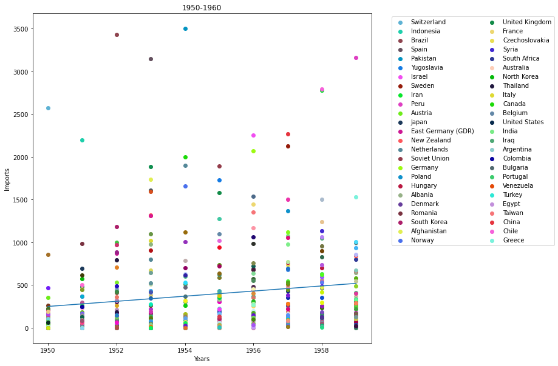

```python
plt.rc('figure', figsize=(10, 10))
m,b = np.polyfit(year_1950_1960,_1950_1960, 1)
regression_line = [(m*x)+b for x in year_1950_1960]
scatter_years_imports(top_50_1950_1960)
plt.plot(year_1950_1960, regression_line)
plt.title("1950-1960")
plt.xlabel("Years")
plt.ylabel("Imports")
plt.show()
```

#### 1950-1960

This time period it is hard to differentiate the signal from the noise per say, because this was the advent of the Cold War. In a world still recovering from a World War. We see many European powers above the linear regression as they were being supplied from global superpowers to face off against each other's power blocs. The reason China and North Korea are signifcantly above the line is because of the Korean War, we don't have the importation prior to 1950.

However, we see both India and Pakistan above the line consistently during this time period. Just 2 years prior to our analysis period they had just concluded one War. With this aggresive spending in the short term, we can see they were preparing for another conflict. Which did indeed arrive in 1965. So they were both upgrading and replenishing their arms for the next conflict.

We see a massive spike in Egypt after their revolution in 1952. Under the leadership of Abdel Nasser Egypt would see many conflict against Israel, who is also above the line. Another intresting relationship appears that between rival nations both spending heavily and quickly on arms. In an anticpation of a fight between each other.

So we do see evidence for our hypothesis, through the short bursts of high volume of arms purchase being a tell tale piece of evidence for future conflict.

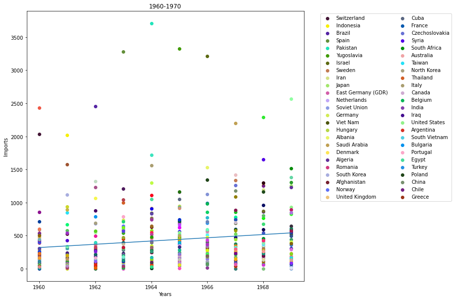

```python
plt.title("1960-1970")
plt.xlabel("Years")
plt.ylabel("Imports")
m,b = np.polyfit(year_1960_1970,_1960_1970, 1)
regression_line = [(m*x)+b for x in year_1960_1970]
scatter_years_imports(top_50_1960_1970)
plt.plot(year_1960_1970, regression_line)
```

#### 1960-1970

We begin to see conflict popping off all over the world during this time period and new powers are entering the fray. The most interesting case is the spike in arms Cuba, which then tapers off over time. This spike was caused by the Cuban Missile crisis,which was solved in 1962. However, Cuba was not even on the radar the previous decade but has leaped it's way onto the leaderboards. What's intresting to see if the entrance of numerous Middle Eastern countries into the top 50.

This would prove to be a prelude to a bloody history of revoloutions,coups, and wars in the Middle East. Countries like Iran,Iraq,Vietnam, and a few others in the top 50 are above the linear regression and did indeed engage in sudden acts of hostility within a few years and the next decade.

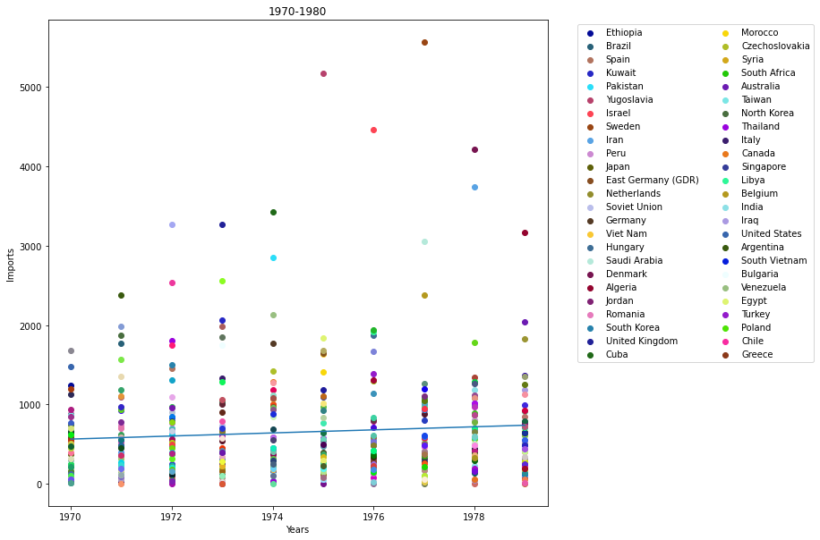

```python
plt.title("1970-1980")
plt.xlabel("Years")
plt.ylabel("Imports")
m,b = np.polyfit(year_1970_1980,_1970_1980, 1)
regression_line = [(m*x)+b for x in year_1970_1980]
scatter_years_imports(top_50_1970_1980)
plt.plot(year_1970_1980, regression_line)
```

#### 1970 - 1980

This time period provides the greatest amount of evidence for our claim.

Iran spends more and more money every year on arms to quell domestic issues, until the Iranian revolution in 1979. Libya has just under gone revolution and the new leader Gaddafi prepares for a future and unexpected war against Egypt. Middle Eastern nations like Egypt, Syria,Iraq,Morroco continue their great arms spending, from the previous decade, for a suprise attack on Israel. Which bolsters the case for our hypothesis.

Argentina slowly climbs up our top 50 list, in prepration for the Falklands War in 1982.Growing tensions between the UK prompted it to take a defensive posture

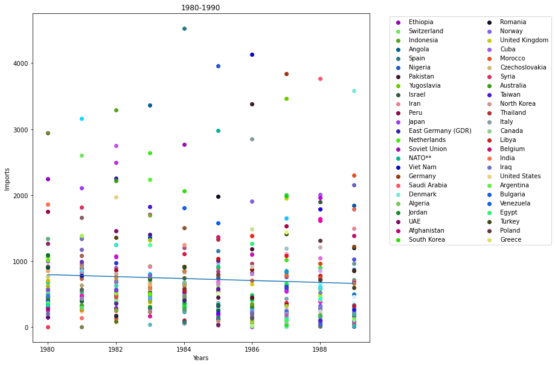

```python
plt.title("1980-1990")
plt.xlabel("Years")
plt.ylabel("Imports")
m,b = np.polyfit(year_1980_1990,_1980_1990, 1)
regression_line = [(m*x)+b for x in year_1980_1990]
scatter_years_imports(top_50_1980_1990)
plt.plot(year_1980_1990, regression_line)
```

#### 1980-1989

Iraq jumps to the top of our list after Sadam Hussein consolidates power. He begins to spend aggresivley in preparation for the invasion of Kuwait in 1990.

Saudi Arabia,Syria,Egypt, and Libia are preparing for coming border conflicts and fearful of Sadam.

For the first time the flow of arms imports flow towards the Middle East more than Europe. Suggesting Europe is slightly more peaceful now due to a weakening Soviet Union.

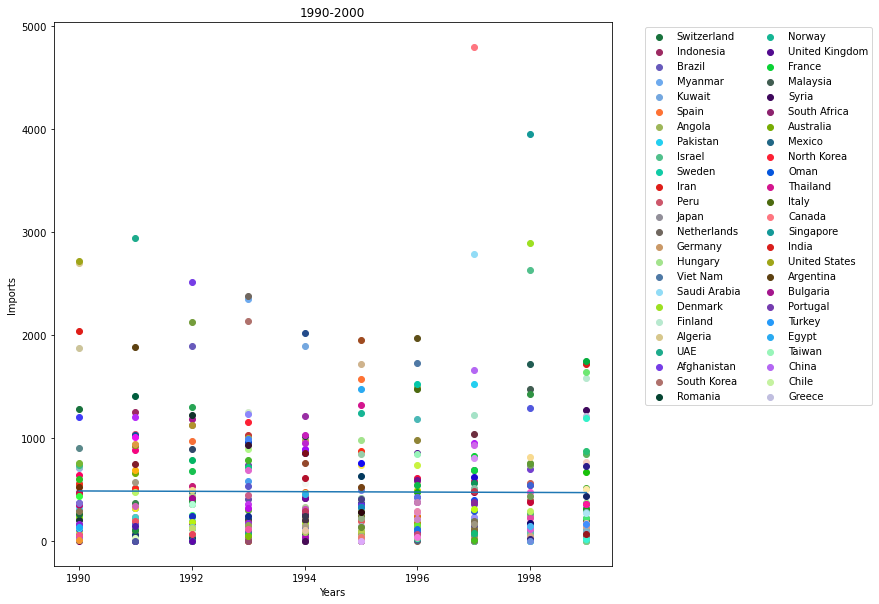

```python
plt.rc('figure', figsize=(10, 10))
plt.title("1990-2000")
plt.xlabel("Years")
plt.ylabel("Imports")
m,b = np.polyfit(year_1990_2000,_1990_2000, 1)
regression_line = [(m*x)+b for x in year_1990_2000]
scatter_years_imports(top_50_1990_2000)
plt.plot(year_1990_2000, regression_line)
```

#### 1990-2000

A military coup in Turkey boosts it to the top of our list as it spends more and more money to hold power and stave off the Kurdish threat at its border.

Notably Iraq falls off the list due to international embargoes due to its' invasion of Kuwait in 1990.'

Saudi Arabia in fear of Iraq begins to stock up on weapons under the guidance of the US.

Afghanistan weapons imports fall harshly after the Soviets are driven out by the mujadheen. The imports drop to 0 but enough weapons have flown into the country to set the events of the next decade. The beginnging of a new kind of warfare.

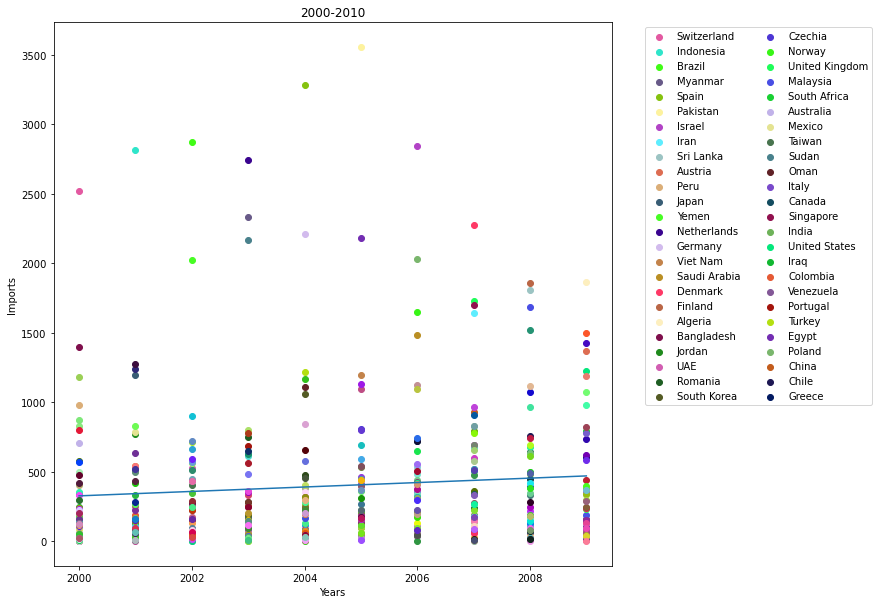

```python
plt.title("2000-2010")
plt.xlabel("Years")
plt.ylabel("Imports")
m,b = np.polyfit(year_2000_2010,_2000_2010, 1)
regression_line = [(m*x)+b for x in year_2000_2010]
scatter_years_imports(top_50_2000_2010)
plt.plot(year_2000_2010, regression_line)
```

#### 2000-2010

War on Terror begins 2001 after the events of 9/11. The US traditonally one of the biggest weapons exporters in the world rises up the list to wage war. US later invades Iraq. We also see UK moving up the list to assist NATO and colition forces.

Iraq returns to the list after a decade of hiding after becoming an American protectrate. Rare case of sudden spending isn't related to aggression but rebuilding the country from scratch.

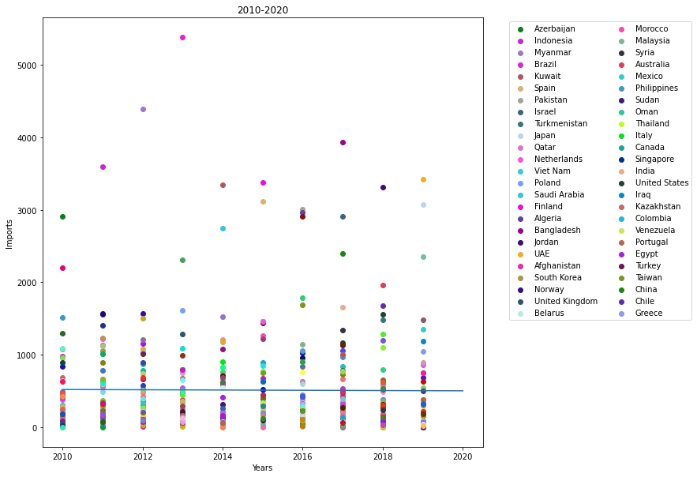

```python
plt.title("2010-2020")
plt.xlabel("Years")
plt.ylabel("Imports")
m,b = np.polyfit(year_2010_2020,_2010_2020, 1)
regression_line = [(m*x)+b for x in year_2010_2020]
scatter_years_imports(top_50_2010_2020)
plt.plot(year_2010_2020, regression_line)
```

#### 2010-2020

India moves to the top of list as they deal with internal issues and prepare to annex Jammu Kashmir as an Indian state. Saudi Arabia begins to prepare their intervention in Baharin and Yemen. China spends aggresivley to establish a precense in the South China Sea, taking advantage of a war weary United States. A spending pattern we observed in the previous decade. Egypt deals with internal issues and coup attempts. UAE seeks to bolster defenses against ISIS.

### Did the Hypothesis hold ?

We see that for a few cases described in the prose for the intervals the hypothesis did hold. However, in some cases like countries like Japan and Germany building their arsenals back for national defense. These nations rely on foreign imports for security but aren't being aggressive on the global scale. If we were to conduct analysis for 2 35 period intervals, we would be able to see the nations that are building their arsenals to become more competitive on a global scale: rather than prepare for a hasty invasion or raid.

Short term and high volume arms purchases did more than often lead to be a prelude to a conflict. So this would suggest there is a relation between these two terms, although not always one to one due to ceasefires or deescaltion through diplomatice channels. A nation prepares for these hasty actions to strike before their target get access to deadlier weapons, like nuclear weapons. An example would be the Arab coalition invading Israel during the 6 day war before they had massive nuclear arsenals.

It would take a keen analyst to identify intense weapons purchasing in conjunction with know geo political issues to identify possible hostile nations. If given access to more resources we could make some sort of an index for geo political heat and add it as an interaction term.

### Conclusion

Since our hypothesis has held for several historical examples, we should be able to use that trend in the modern era. However, we must keep in mind the geopolitical situation while making those decisions. Any nation that spends above the the linear regression of the top 50 should be kept in the sights of our nation.

Let us now look for a few intresting cases of where countries are importing above the line of regression with known geopoltical issues.

If we look at the modern era 2010-2020. We see aggressive spending among central asian countries. Azerbijan has already and suddenly attacked Armenia.Kazakhstan and Turkmenistan have also exhibited similar spending patterns suggesting that they are preparing for something as well.

Myanmar recently had a military coup and in our graph we see Myanmar is a little above the standard. This suggest the military premeditated this coup and has been stockpiling weapons to carry it out.Therefore this coup isn't because of "electoral fraud" as claimed by the military junta, but rather a well planned strategy.